# Summary statistics and law of large numbers

# Introduction to summary statistics and to the Law of large number

## What will we learn in this empirical example ?

1. Importing data in Python.
2. Computing averages and summary statistics.
3. Applying the law of large numbers for estimating a covariance matrix.
4. Finding the portfolio with the smallest variance.

## Theory behind the empirical exercise

In this short document, we show how to compute the weights of the financial portfolio exhibiting the smallest variance. Assuming that we have a universe of N asset returns $X=(X_1,...,X_N)'$. We want to choose the portfolio that exhibits the smallest variance in this universe. As a reminder, the optimal portfolio solves the following optimization program

$$\hat{\omega} = \text{argmin}_{\omega} w' \Sigma w ~~\text{such that } \sum_{i=1}^{N}\omega_i = 1,$$
in which $\Sigma = \text{V}(X)$, i.e. the covariance matrix of the asset returns. To do so, we need an estimate of the covariance matrix $\Sigma$. Denoting $x_t=(x_{t,1},...,x_{t,N})'$, the N asset returns observed at time $t$, the law of large numbers tells us that
$$\Sigma \approx \frac{1}{T}\sum_{t=1}^{T}(x_t-\bar{x})(x_t-\bar{x})'$$
in which $\bar{x} = \frac{1}{T}\sum_{t=1}^{T}x_t$.

## From theory to practice

To begin with, we import the daily returns from the excel file *SP500_asset_returns.csv*. The file contains daily returns of most assets represented in the S&P 500.

```python
import matplotlib.pyplot as plt
import pandas as pd
import numpy as np
import seaborn as sns
from scipy.stats import norm
from numpy.linalg import inv
url="https://raw.githubusercontent.com/adufays/GDP_expectancy/main/SP500_asset_returns.csv"
data = pd.read_csv(url,sep=",")
print(data)
```

```
##      Unnamed: 0        Date       MMM  ...      XLNX        XL       YUM
## 0             1  2015-10-06 -0.003629  ...  0.009124 -0.007460  0.004445
## 1             2  2015-10-07  0.011932  ...  0.009716  0.015137 -0.208654
## 2             3  2015-10-08  0.013063  ...  0.014954  0.012487 -0.003699
## 3             4  2015-10-09  0.002806  ... -0.005331 -0.002160  0.040526
## 4             5  2015-10-12  0.001067  ... -0.004688  0.004047  0.008364
## ..          ...         ...       ...  ...       ...       ...       ...
## 496         497  2017-09-25 -0.000142  ...  0.001729  0.005598 -0.026949
## 497         498  2017-09-26  0.001423  ...  0.001007 -0.030399 -0.007465
## 498         499  2017-09-27 -0.007372  ...  0.013005 -0.006298 -0.004096
## 499         500  2017-09-28  0.000334  ... -0.003413  0.029055  0.005457
## 500         501  2017-09-29  0.001669  ...  0.009077  0.008656  0.001495
##
## [501 rows x 386 columns]
```

```python
ret_IBM = np.array(data.IBM,ndmin=2)
```

## Summary statistics

We can have a closer look to the asset returns. First, we focus on one asset and look at the different quantiles of the series. The R function *summary* provides the 25%, 50% (Median) and 75% quantiles as well as the min and the max of the series. We observe that the IBM asset returns are between -5.9% and 4.9% over this period.

```python
def summary(y):
    y = np.array(y,ndmin=2)
    K = np.size(y,0)
    nobs = np.size(y,1)
    quant = np.linspace(25,100,4)/100
    Stats = np.zeros([K,6])
    for i in range(0,K):
        Stats[i,0] = np.min(y[i,:])
        quantile = np.quantile(ret_IBM,quant)
        Stats[i,[1,2,4,5]] = quantile
        Stats[i,3] = np.mean(y[i,:])

    df=pd.DataFrame(Stats,columns=["Min.","1st. Qu.","Median","Mean","3rd Quar.","Max."])
    return(df)

print(summary(ret_IBM))
```

```
##        Min.  1st. Qu.    Median      Mean  3rd Quar.     Max.
## 0 -0.059218 -0.005599  0.000262 -0.000054   0.005583  0.04913
```

## Creating its own summary statistics

We now build a function that will compute important summary statisitics such as the mean, the standard deviation, the skewness and the excess kurtosis.

```python
def mystats(y):
    y = np.array(y,ndmin=2)
    K = np.size(y,0)
    nobs = np.size(y,1)
    Stats = np.zeros([K,5])
    for i in range(0,K):
        mean = np.mean(y[i,:])
        std = np.std(y[i,:])
        Stats[i,0] = np.size(y,1)
        Stats[i,1] = mean
        Stats[i,2] = std
        Stats[i,3] = (np.sum((y[i,:]-mean)**3)/std**3)/nobs
        Stats[i,4] = (np.sum((y[i,:]-mean)**4)/std**4)/nobs - 3
        df=pd.DataFrame(Stats,columns=["Obs","Mean","St dev.","Skewness","Ex. Kurtosis"])
    return(df)
```

Calling *mystats* for IBM or for two other returns gives the following results:

```python
print(mystats(ret_IBM))
```

```
##      Obs      Mean  St dev.  Skewness  Ex. Kurtosis
## 0  501.0 -0.000054  0.01135 -1.003165      5.855791
```

```python
print(mystats(np.array([data.IBM, data.AAPL],ndmin=2)))
```

```
##      Obs      Mean   St dev.  Skewness  Ex. Kurtosis
## 0  501.0 -0.000054  0.011350 -1.003165      5.855791
## 1  501.0  0.000659  0.013639 -0.086726      4.112331
```

The summary statistics show that IBM returns are skewed (compared to a Normal distribution) and exhibit a high kurtosis. We can plot the series and observe the large negative and positive returns.

```python
data['Date'] = pd.to_datetime(data['Date'])
Date = data.Date
# Create figure and plot space
fig, ax = plt.subplots(figsize=(10, 10))
# Add x-axis and y-axis
ax.plot(Date,np.transpose(ret_IBM),color='purple')
# Set title and labels for axes
ax.set(xlabel="Date", ylabel="Returns in %",title="IBM daily returns over time")
# Rotate tick marks on x-axis
```

```
## [Text(0, 0.5, 'Returns in %'), Text(0.5, 0, 'Date'), Text(0.5, 1.0, 'IBM daily returns over time')]
```

```python
plt.setp(ax.get_xticklabels(), rotation=45)
```

```
## [None, None, None, None, None, None, None, None, None, None, None, None, None, None, None, None, None, None]
```

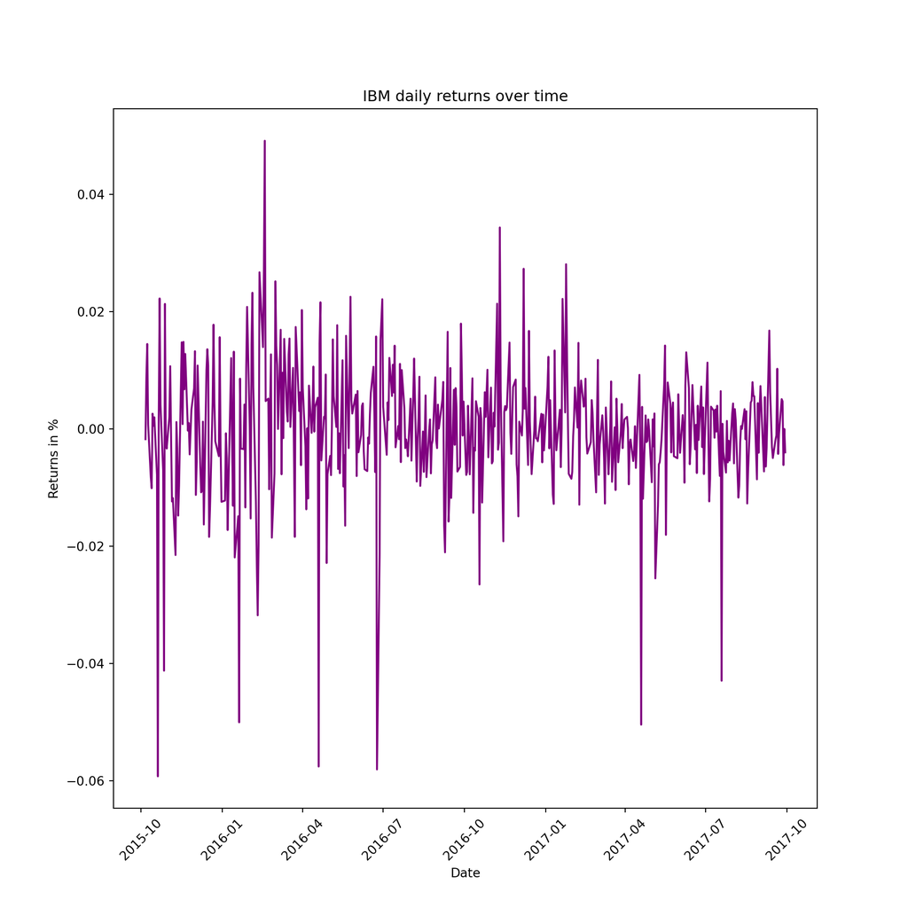

```python
plt.show()
```

Let us compare the IBM returns with a Normal distribution. We have studied an unbiased estimate of the expectation and of the variance. As other estimators, we can also invoke the law of large Numbers (LLN) and use a biased but consistent estimator for the variance. Using one of these estimators for the expectation and the variance, we can compare our series with draws sampled from a Normal distribution with moments equal to the IBM expectation and variance.

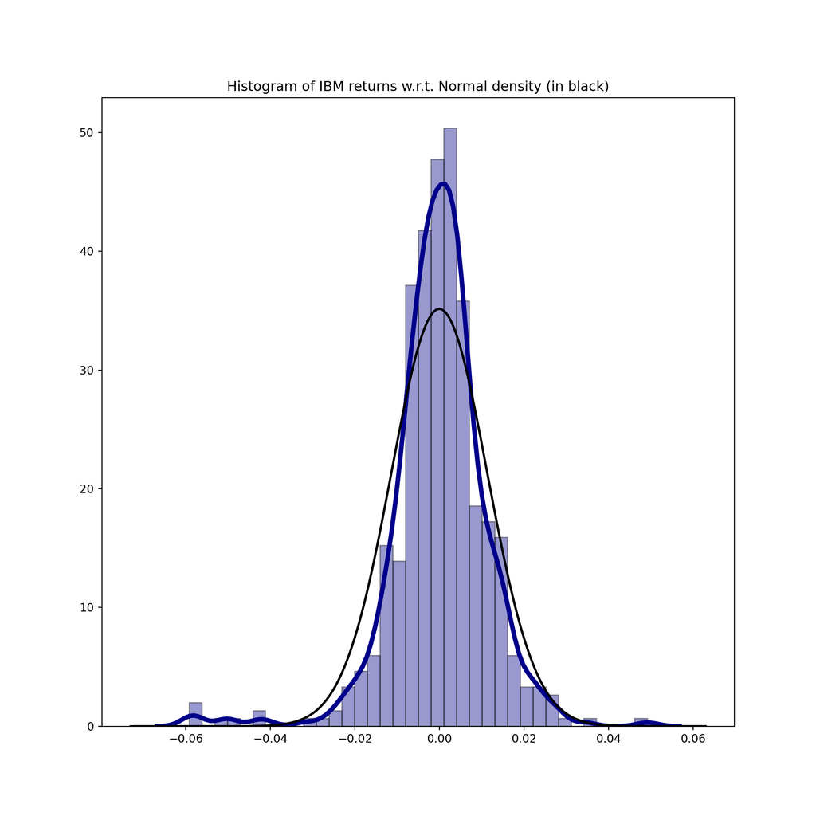

```python
# Fit a normal distribution to the data:
mu_std = norm.fit(ret_IBM)
# Plot the histogram.
sns.distplot(np.transpose(ret_IBM), hist=True, kde=True,
             bins=int(180/5), color = 'darkblue',
             hist_kws={'edgecolor':'black'},
             kde_kws={'linewidth': 4})
#plt.hist(np.transpose(ret_IBM), bins=100, color='purple',edgecolor = 'black')
# Plot the PDF.
xmin, xmax = plt.xlim()
x = np.linspace(xmin, xmax, 1000)
density = norm.pdf(x, mu_std[0], mu_std[1])
plt.plot(x, density, 'k', linewidth=2)
plt.title("Histogram of IBM returns w.r.t. Normal density (in black)")
plt.show()
```

# Risk minimization

Now, we turn to the computation of the portfolio weights that minimize the variance. First, we need an estimate of the covariance matrix.

```python
get_data = np.array(data,ndmin=2)
returns_universe = np.array(get_data[:,2:12],dtype=float)
Mean_ret = np.array(np.mean(returns_universe,0),ndmin=2,dtype=float)
df_Mean_ret=pd.DataFrame(Mean_ret,columns=data.columns[2:12])
print(df_Mean_ret)
```

```
##        MMM       ABT      ATVI      ADBE  ...      AMG       AFL         A       APD
## 0  0.00072  0.000507  0.001401  0.001103  ...  0.00017  0.000631  0.001192  0.000413
##
## [1 rows x 10 columns]
```

```python
T = np.size(returns_universe,0)
N = np.size(returns_universe,1)
Sigma_hat = np.zeros([N,N],dtype=float)
for t in range(0,T):
    error = np.transpose(returns_universe[t,:] - Mean_ret)
    Sigma_hat = Sigma_hat + np.dot(error,np.transpose(error))/(T-1)
```

You could also estimate the covariance matrix using the *cov* function. It does the same computation as above.

```python
Sigma_hat2 = np.cov(np.transpose(returns_universe),bias=False)
print(np.sum(np.abs(Sigma_hat2-Sigma_hat)))
```

```
## 5.2244992186645245e-18
```

## Estimation of the weights

We have an estimation of the covariance matrix. We can plug this estimate into the formula (see the corresponding slides) to get an estimate of the weights.

```python
vect_ones = np.zeros([N,1],dtype = float)+1
inv_Sigma = inv(Sigma_hat)
omega = np.dot(inv_Sigma,vect_ones)/(np.dot(np.dot(np.transpose(vect_ones),inv_Sigma),vect_ones))
print(omega)
```

```
## [[ 0.35881889]
##  [ 0.07988919]
##  [ 0.04023733]
##  [ 0.02864103]
##  [ 0.02730065]
##  [ 0.11109478]
##  [-0.15682242]
##  [ 0.35344862]
##  [-0.00381349]
##  [ 0.16120541]]
```